# Bike Sharing

## Week 1 (Exploratory Data Analysis)

```python
!pip install xgboost
```

```
     |████████████████████████████████| 166.7 MB 8.3 kB/s  eta 0:00:01
```

```python
# Importing required libraries
import pandas as pd
import numpy as np
import matplotlib.pyplot as plt
import seaborn as sns
from sklearn.ensemble import RandomForestRegressor
from sklearn.feature_selection import SelectFromModel
from sklearn.model_selection import train_test_split
from sklearn import ensemble
from sklearn.linear_model import LinearRegression
from sklearn.tree import DecisionTreeRegressor
import xgboost
from sklearn.model_selection import KFold
from sklearn.preprocessing import MinMaxScaler
from sklearn.pipeline import Pipeline
from sklearn.compose import TransformedTargetRegressor
from sklearn.model_selection import cross_val_score
from sklearn import metrics
```

```python
# Creating dataframe
dataframe = pd.read_csv('s3://bike-sharing/train.csv')
dataframe.head()
```

|  | datetime | season | holiday | workingday | weather | temp | atemp | humidity | windspeed | casual | registered | count |
| --- | --- | --- | --- | --- | --- | --- | --- | --- | --- | --- | --- | --- |
| 0 | 2011-01-01 00:00:00 | 1 | 0 | 0 | 1 | 9.84 | 14.395 | 81 | 0.0 | 3 | 13 | 16 |
| 1 | 2011-01-01 01:00:00 | 1 | 0 | 0 | 1 | 9.02 | 13.635 | 80 | 0.0 | 8 | 32 | 40 |
| 2 | 2011-01-01 02:00:00 | 1 | 0 | 0 | 1 | 9.02 | 13.635 | 80 | 0.0 | 5 | 27 | 32 |
| 3 | 2011-01-01 03:00:00 | 1 | 0 | 0 | 1 | 9.84 | 14.395 | 75 | 0.0 | 3 | 10 | 13 |
| 4 | 2011-01-01 04:00:00 | 1 | 0 | 0 | 1 | 9.84 | 14.395 | 75 | 0.0 | 0 | 1 | 1 |

```python
dataframe.shape
```

```
(10886, 12)
```

We have 12 columns and 10886 rows in our train dataset

```python
dataframe.info()
```

```
<class 'pandas.core.frame.DataFrame'>
RangeIndex: 10886 entries, 0 to 10885
Data columns (total 12 columns):
 #   Column      Non-Null Count  Dtype
---  ------      --------------  -----
 0   datetime    10886 non-null  object
 1   season      10886 non-null  int64
 2   holiday     10886 non-null  int64
 3   workingday  10886 non-null  int64
 4   weather     10886 non-null  int64
 5   temp        10886 non-null  float64
 6   atemp       10886 non-null  float64
 7   humidity    10886 non-null  int64
 8   windspeed   10886 non-null  float64
 9   casual      10886 non-null  int64
 10  registered  10886 non-null  int64
 11  count       10886 non-null  int64
dtypes: float64(3), int64(8), object(1)
memory usage: 1020.7+ KB
```

We have

- 3 float type columns
- 8 integer type columns
- 1 object type column

Since datetime is object type data, we will split datetime into columns ie month(int), day(int 0-6/Mon-Sun) and hour(int)

```python
# Adding time and month to the dataframe using datatime column
from datetime import datetime

hour=[]
day=[]
month=[]

for i in dataframe['datetime']:
    date = datetime.strptime(i,"%Y-%m-%d %H:%M:%S")
    hour.append(date.hour)
    day.append(date.weekday())
    month.append(date.month)

dataframe['hour'] = pd.DataFrame(hour).astype(int)
dataframe['day'] = pd.DataFrame(day).astype(int)
dataframe['month'] = pd.DataFrame(month).astype(int)

# Dropping datetime column
dataframe.drop('datetime',axis=1,inplace=True)
```

```python
dataframe.info()
```

```
<class 'pandas.core.frame.DataFrame'>
RangeIndex: 10886 entries, 0 to 10885
Data columns (total 14 columns):
 #   Column      Non-Null Count  Dtype
---  ------      --------------  -----
 0   season      10886 non-null  int64
 1   holiday     10886 non-null  int64
 2   workingday  10886 non-null  int64
 3   weather     10886 non-null  int64
 4   temp        10886 non-null  float64
 5   atemp       10886 non-null  float64
 6   humidity    10886 non-null  int64
 7   windspeed   10886 non-null  float64
 8   casual      10886 non-null  int64
 9   registered  10886 non-null  int64
 10  count       10886 non-null  int64
 11  hour        10886 non-null  int64
 12  day         10886 non-null  int64
 13  month       10886 non-null  int64
dtypes: float64(3), int64(11)
memory usage: 1.2 MB
```

Now, we have

- 3 float type columns
- 11 integer type columns

```python
# Checking for null values
dataframe.isnull().sum()
```

```
season        0
holiday       0
workingday    0
weather       0
temp          0
atemp         0
humidity      0
windspeed     0
casual        0
registered    0
count         0
hour          0
day           0
month         0
dtype: int64
```

Since the count is zero there are no null values

```python
# Checking for duplicates
duplicates = dataframe.duplicated()
print(duplicates.sum())
```

```
1
```

We have 1 duplicate rows in dataset

```python
# Removing duplicates
dataframe.drop_duplicates(inplace=True)
```

```
<function matplotlib.pyplot.show(close=None, block=None)>
```

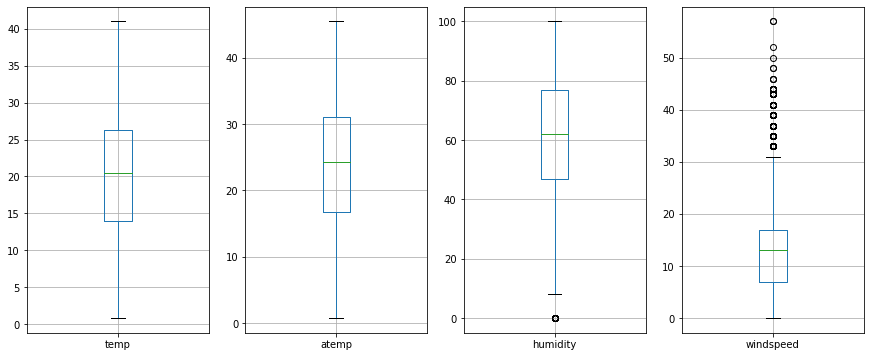

```python
# Checking for outliers using boxplot
plt.figure(figsize=(15,6))
plt.subplot(141)
dataframe.boxplot(column=["temp"])
plt.subplot(142)
dataframe.boxplot(column=["atemp"])
plt.subplot(143)
dataframe.boxplot(column=["humidity"])
plt.subplot(144)
dataframe.boxplot(column=["windspeed"])
plt.show
```

We have some outliers in humidity and windspeed

```python
def remove_outlier(col):
    sorted(col)
    Q1,Q3 = col.quantile([0.25,0.75])
    IQR = Q3-Q1
    lower_range = Q1-(1.5*IQR)
    upper_range = Q3+(1.5*IQR)
    return lower_range,upper_range
```

```python
# Removing outliers for humidity and windspeed
low_humidity,up_humidity = remove_outlier(dataframe['humidity'])
dataframe['humidity'] = np.where(dataframe['humidity']>up_humidity,up_humidity,dataframe['humidity'])
dataframe['humidity'] = np.where(dataframe['humidity']<low_humidity,low_humidity,dataframe['humidity'])

low_windspeed,up_windspeed = remove_outlier(dataframe['windspeed'])
dataframe['windspeed'] = np.where(dataframe['windspeed']>up_windspeed,up_windspeed,dataframe['windspeed'])
dataframe['windspeed'] = np.where(dataframe['windspeed']<low_windspeed,low_windspeed,dataframe['windspeed'])
```

### Heatmap for correlation (Bivariate Analysis)

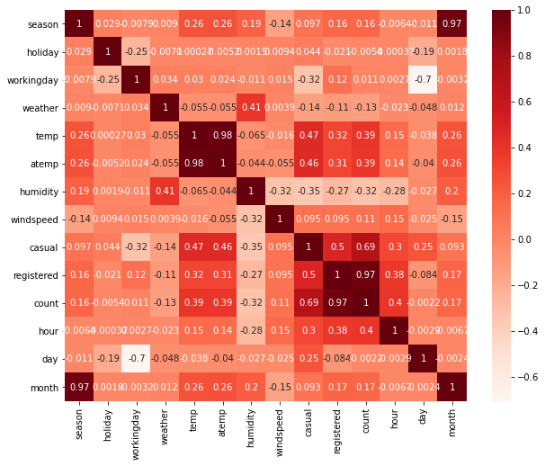

```python
plt.figure(figsize=(10,8))
sns.heatmap(dataframe.corr(),cmap='Reds',annot=True)
```

We can see

- season and month are highly correlated
- registered and count are highly correlated
- temp and atemp are highly correlated

## Week 2 (Data Visualization & Feature Engineering)

#### Weather Types:

1. (Good) Clear, Few clouds, Partly cloudy
2. (Normal) Mist + Cloudy, Mist + Broken clouds, Mist + Few clouds, Mist
3. (Bad) Light Snow and Rain + Thunderstorm + Scattered clouds, Light Rain + Scattered clouds
4. (Worst) Heavy Rain + Ice Pallets + Thunderstorm + Mist, Snow + Fog

Some box plots

```python
import matplotlib.patheffects as path_effects
def add_median_labels(ax):
    lines = ax.get_lines()
    # determine number of lines per box (this varies with/without fliers)
    boxes = [c for c in ax.get_children() if type(c).__name__ == 'PathPatch']
    lines_per_box = int(len(lines) / len(boxes))
    # iterate over median lines
    for median in lines[4:len(lines):lines_per_box]:
        # display median value at center of median line
        x, y = (data.mean() for data in median.get_data())
        # choose value depending on horizontal or vertical plot orientation
        value = x if (median.get_xdata()[1]-median.get_xdata()[0]) == 0 else y
        text = ax.text(x, y, f'{value:.1f}', ha='center', va='center',
                       fontweight='bold', color='white')
        # create median-colored border around white text for contrast
        text.set_path_effects([
            path_effects.Stroke(linewidth=3, foreground=median.get_color()),
            path_effects.Normal(),
        ])
```

```
<function matplotlib.pyplot.show(close=None, block=None)>
```

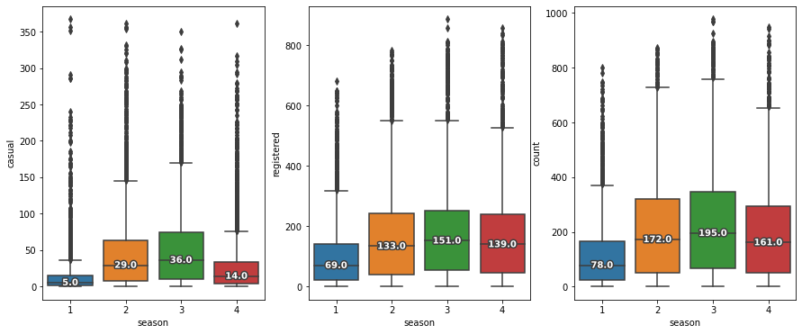

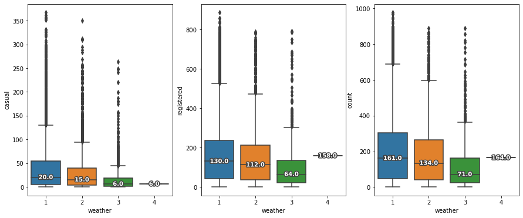

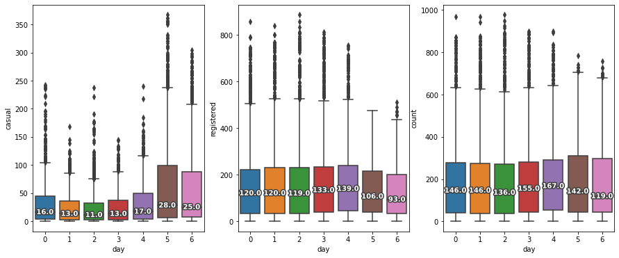

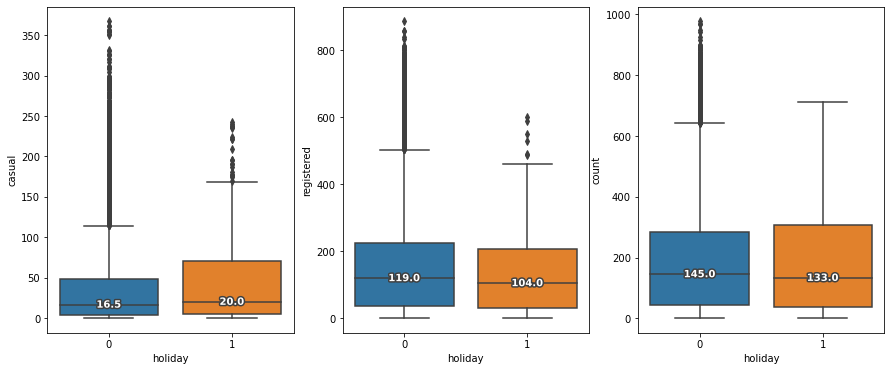

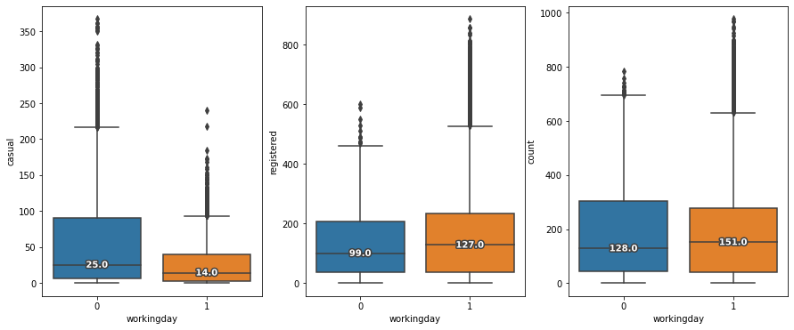

```python
cols = ['season','weather','day','holiday','workingday']
cols2 = ['casual','registered','count']
for col in cols:
    plt.figure(figsize=(15,6))
    for i,v in enumerate(cols2):
        plt.subplot(131+i)
        box_plot = sns.boxplot(x=col,y=v,data=dataframe)
        add_median_labels(box_plot.axes)
plt.show
```

- Casual count is less in spring and winter
- Registered count is less in spring

## - More count in sunny and cloudy days

- Casual count is 47% less on week days than weekends
- Registered count is 23% more on week days than weekends

## - Casual count is 21% more on holidays than working days

- Casual count is 44% lesser on working days than non working days
- Registered count is 28% more on working days than non working days

#### Pointplot of avg count grouped by hour for every season

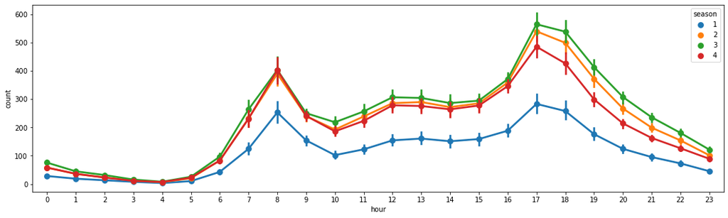

```python
# Seasons: 1 = spring, 2 = summer, 3 = fall, 4 = winter

fig, ax = plt.subplots(figsize=(18, 5))
sns.pointplot(x=dataframe['hour'], y=dataframe['count'],hue=dataframe['season'], ax=ax)
```

Season-3 (fall) has most count of users and season-1 (spring) has least count of users on hourly basis

#### Pointplot of avg count grouped by hour for every weekday

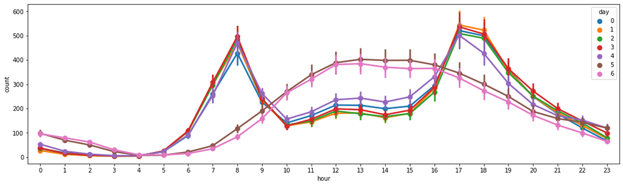

```python
# Day: 0(Monday)-6(Sunday)

fig, ax = plt.subplots(figsize=(18, 5))
sns.pointplot(x=dataframe['hour'], y=dataframe['count'],hue=dataframe['day'], ax=ax)
```

Weekends and weekdays have different trends of count of users on hourly basis

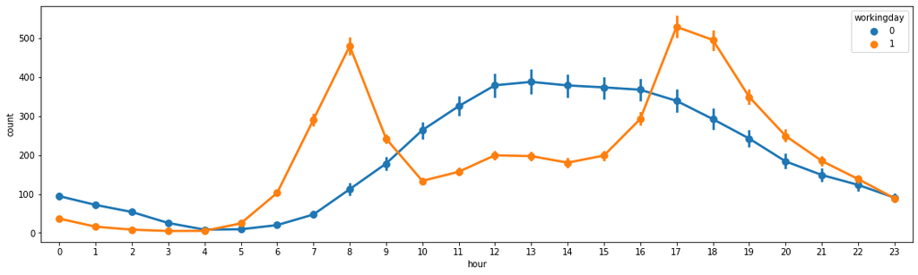

```python
fig, ax = plt.subplots(figsize=(18, 5))
sns.pointplot(x=dataframe['hour'], y=dataframe['count'],hue=dataframe['workingday'], ax=ax)
```

- 8, 17 & 18 are peak hours on working days
- 11-17 are peak hours on holidays

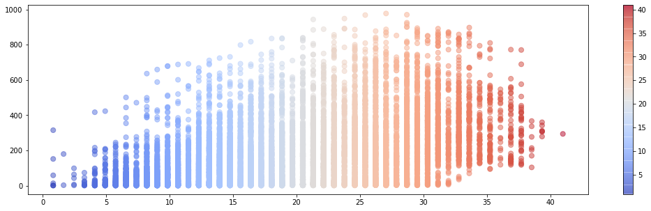

```python
fig, ax = plt.subplots(figsize=(18, 5))
cmap = sns.color_palette("coolwarm", as_cmap=True)
points = ax.scatter(dataframe['temp'], dataframe['count'], c=dataframe['temp'], s=50, cmap=cmap,alpha=0.5)
fig.colorbar(points)
```

Higher temperature favours more count

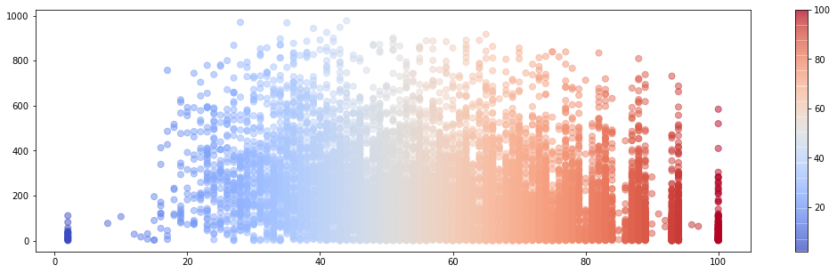

```python
fig, ax = plt.subplots(figsize=(18, 5))
cmap = sns.color_palette("coolwarm", as_cmap=True)
points = ax.scatter(dataframe['humidity'], dataframe['count'], c=dataframe['humidity'], s=50, cmap=cmap,alpha=0.5)
fig.colorbar(points)
```

Lower humidity favours more count

### Feature Engineering

Looking from above visualizations we can add another feature "peak" to signify whether it is a peak hour or not

```python
# Adding a feature "peak"
dataframe['peak'] = dataframe[['hour','workingday']].apply(lambda df: 1 if ((df['workingday'] == 1 and (df['hour'] in [8,17,18])) or (df['workingday'] == 0 and 11 <= df['hour'] and df['hour'] <= 17)) else 0, axis = 1)
```

```python
# Normalizing data (min-max normalization)
# ndf=(dataframe-dataframe.min())/(dataframe.max()-dataframe.min())
ndf = dataframe
ndf.head()
```

|  | season | holiday | workingday | weather | temp | atemp | humidity | windspeed | casual | registered | count | hour | day | month | peak |
| --- | --- | --- | --- | --- | --- | --- | --- | --- | --- | --- | --- | --- | --- | --- | --- |
| 0 | 1 | 0 | 0 | 1 | 9.84 | 14.395 | 81.0 | 0.0 | 3 | 13 | 16 | 0 | 5 | 1 | 0 |
| 1 | 1 | 0 | 0 | 1 | 9.02 | 13.635 | 80.0 | 0.0 | 8 | 32 | 40 | 1 | 5 | 1 | 0 |
| 2 | 1 | 0 | 0 | 1 | 9.02 | 13.635 | 80.0 | 0.0 | 5 | 27 | 32 | 2 | 5 | 1 | 0 |
| 3 | 1 | 0 | 0 | 1 | 9.84 | 14.395 | 75.0 | 0.0 | 3 | 10 | 13 | 3 | 5 | 1 | 0 |
| 4 | 1 | 0 | 0 | 1 | 9.84 | 14.395 | 75.0 | 0.0 | 0 | 1 | 1 | 4 | 5 | 1 | 0 |

```python
x_train = ndf.drop(['casual','registered','count'], axis=1)
y_train_c = ndf['casual']
y_train_r = ndf['registered']
```

```python
sel1 = SelectFromModel(RandomForestRegressor(n_estimators = 100))
sel1.fit(x_train, y_train_c)
```

```
SelectFromModel(estimator=RandomForestRegressor())
```

```python
(sel1.get_support())
```

```
array([False, False,  True, False,  True,  True, False, False,  True,
       False, False,  True])
```

```python
sel1.estimator_.feature_importances_
```

```
array([0.0076997 , 0.00433863, 0.13403978, 0.00841664, 0.14994304,
       0.13379672, 0.07445205, 0.0270899 , 0.14028713, 0.05109642,
       0.0276743 , 0.2411657 ])
```

```python
selected_feat= x_train.columns[(sel1.get_support())]
print(selected_feat)
```

```
Index(['workingday', 'temp', 'atemp', 'hour', 'peak'], dtype='object')
```

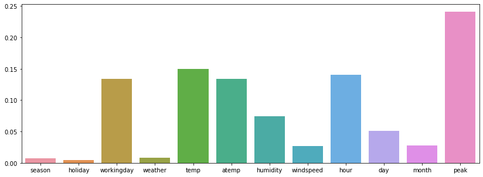

```python
plt.subplots(figsize=(14, 5))
sns.barplot(x=x_train.columns,y=sel1.estimator_.feature_importances_)
```

```python
sel2 = SelectFromModel(RandomForestRegressor(n_estimators = 10))
sel2.fit(x_train, y_train_r)
```

```
SelectFromModel(estimator=RandomForestRegressor(n_estimators=10))
```

```python
sel2.estimator_.feature_importances_
```

```
array([0.02251535, 0.00113572, 0.11957641, 0.0221503 , 0.04511825,
       0.03368976, 0.05565868, 0.02976197, 0.24368612, 0.0332683 ,
       0.05833701, 0.33510213])
```

```python
selected_feat= x_train.columns[(sel2.get_support())]
print(selected_feat)
```

```
Index(['workingday', 'hour', 'peak'], dtype='object')
```

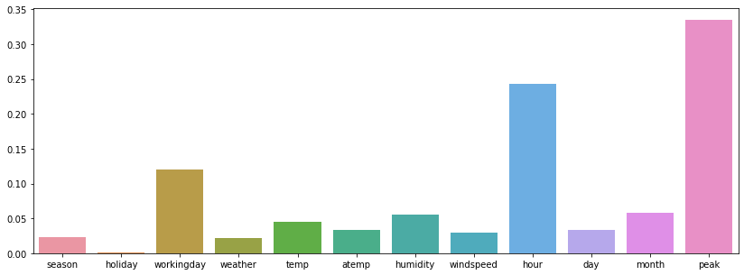

```python
plt.subplots(figsize=(14, 5))
sns.barplot(x=x_train.columns,y=sel2.estimator_.feature_importances_)
```

## Week 4 (Training Models)

### Training Models for predicting casual

```python
x = dataframe.drop(['casual','registered','count'], axis=1)
y = dataframe['casual']
```

```python
# Funtion to calculate RMSE Error
def rmse(y_pred, y_actual):
    diff = y_pred - y_actual
    mean_error = np.square(diff).mean()
    return np.sqrt(mean_error)
```

```python
def test_n_check(x,y,regressor):
    pipeline = Pipeline(steps=[('normalize', MinMaxScaler()), ('model', regressor)])
    model = TransformedTargetRegressor(regressor=pipeline, transformer=MinMaxScaler())

    # for Cross validation (5 folds)
    cv = KFold(n_splits=5, shuffle=True, random_state=1)

    # Training, predicting and getting scores
    scores = cross_val_score(model, x, y, scoring='neg_root_mean_squared_error', cv=cv)

    # Making error positive
    scores = np.absolute(scores)

    # Getting mean of all scores
    s_mean = np.mean(scores)

    return (str(regressor).split('(')[0], s_mean, list(x.columns))
```

#### For casual

```python
x = dataframe.drop(['casual','registered','count'], axis=1)
y = dataframe['casual']
```

```python
results = []
```

```python
regressors = [
    LinearRegression(fit_intercept=True),
    DecisionTreeRegressor(criterion="mse", random_state=0),
    RandomForestRegressor(n_estimators=100,criterion='mse',random_state=0),
    ensemble.AdaBoostRegressor(n_estimators=100,loss='square',random_state=0),
    ensemble.GradientBoostingRegressor(),
    xgboost.XGBRegressor()
]
```

```python
for regressor in regressors:
    results.append(test_n_check(x,y,regressor))
```

```python
x = dataframe.drop(['casual','registered','count','season','holiday','weather'], axis=1)
y = dataframe['casual']
```

```python
regressors1 = [
    LinearRegression(fit_intercept=True),
    DecisionTreeRegressor(criterion="mse", random_state=0),
    RandomForestRegressor(n_estimators=100,criterion='mse',random_state=0),
    ensemble.AdaBoostRegressor(n_estimators=100,loss='square',random_state=0),
    ensemble.GradientBoostingRegressor(),
    xgboost.XGBRegressor()
]
```

```python
for regressor in regressors1:
    results.append(test_n_check(x,y,regressor))
```

```python
results.sort(key=lambda x: x[1])
```

```python
rdf = pd.DataFrame(results,columns=['Model','Mean Score','Columns'])
rdf
```

|  | Model | Mean Score | Columns |
| --- | --- | --- | --- |
| 0 | XGBRegressor | 16.313529 | [season, holiday, workingday, weather, temp, a... |
| 1 | XGBRegressor | 16.372281 | [workingday, temp, atemp, humidity, windspeed,... |
| 2 | RandomForestRegressor | 16.956089 | [season, holiday, workingday, weather, temp, a... |
| 3 | RandomForestRegressor | 17.048839 | [workingday, temp, atemp, humidity, windspeed,... |
| 4 | GradientBoostingRegressor | 20.837821 | [season, holiday, workingday, weather, temp, a... |
| 5 | GradientBoostingRegressor | 20.971193 | [workingday, temp, atemp, humidity, windspeed,... |
| 6 | DecisionTreeRegressor | 23.627683 | [season, holiday, workingday, weather, temp, a... |
| 7 | DecisionTreeRegressor | 23.734236 | [workingday, temp, atemp, humidity, windspeed,... |
| 8 | AdaBoostRegressor | 31.654409 | [season, holiday, workingday, weather, temp, a... |
| 9 | AdaBoostRegressor | 32.921994 | [workingday, temp, atemp, humidity, windspeed,... |
| 10 | LinearRegression | 33.030492 | [season, holiday, workingday, weather, temp, a... |
| 11 | LinearRegression | 33.043176 | [workingday, temp, atemp, humidity, windspeed,... |

#### For Registered

```python
x = dataframe.drop(['casual','registered','count'], axis=1)
y = dataframe['registered']
```

```python
results = []
```

```python
regressors = [
    LinearRegression(fit_intercept=True),
    DecisionTreeRegressor(criterion="mse", random_state=0),
    RandomForestRegressor(n_estimators=100,criterion='mse',random_state=0),
    ensemble.AdaBoostRegressor(n_estimators=100,loss='square',random_state=0),
    ensemble.GradientBoostingRegressor(),
    xgboost.XGBRegressor()
]
```

```python
for regressor in regressors:
    results.append(test_n_check(x,y,regressor))
```

```python
x = dataframe.drop(['casual','registered','count','holiday','weather'], axis=1)
y = dataframe['registered']
```

```python
regressors1 = [
    LinearRegression(fit_intercept=True),
    DecisionTreeRegressor(criterion="mse", random_state=0),
    RandomForestRegressor(n_estimators=100,criterion='mse',random_state=0),
    ensemble.AdaBoostRegressor(n_estimators=100,loss='square',random_state=0),
    ensemble.GradientBoostingRegressor(),
    xgboost.XGBRegressor()
]
```

```python
for regressor in regressors1:
    results.append(test_n_check(x,y,regressor))
```

```python
results.sort(key=lambda x: x[1])
```

```python
rdf = pd.DataFrame(results,columns=['Model','Mean Score','Columns'])
rdf
```

|  | Model | Mean Score | Columns |
| --- | --- | --- | --- |
| 0 | XGBRegressor | 53.522456 | [season, holiday, workingday, weather, temp, a... |
| 1 | XGBRegressor | 55.012871 | [season, workingday, temp, atemp, humidity, wi... |
| 2 | RandomForestRegressor | 57.066638 | [season, holiday, workingday, weather, temp, a... |
| 3 | RandomForestRegressor | 58.540577 | [season, workingday, temp, atemp, humidity, wi... |
| 4 | GradientBoostingRegressor | 65.801594 | [season, holiday, workingday, weather, temp, a... |
| 5 | GradientBoostingRegressor | 66.736372 | [season, workingday, temp, atemp, humidity, wi... |
| 6 | DecisionTreeRegressor | 77.431706 | [season, holiday, workingday, weather, temp, a... |
| 7 | DecisionTreeRegressor | 78.406558 | [season, workingday, temp, atemp, humidity, wi... |
| 8 | LinearRegression | 102.341514 | [season, holiday, workingday, weather, temp, a... |
| 9 | AdaBoostRegressor | 102.515921 | [season, workingday, temp, atemp, humidity, wi... |
| 10 | LinearRegression | 102.683905 | [season, workingday, temp, atemp, humidity, wi... |
| 11 | AdaBoostRegressor | 106.221597 | [season, holiday, workingday, weather, temp, a... |

## Week 5

### Hyperparameter tuning

```python
from sklearn.model_selection import GridSearchCV
from sklearn.model_selection import RandomizedSearchCV
```

### Casual

```python
x = dataframe.drop(['casual','registered','count'], axis=1)
y = dataframe['casual']
```

```python
x_train, x_test, y_train, y_test = train_test_split(x,y,test_size=0.2)
```

### Random Search (Random Forest)

```python
# Number of trees in random forest
n_estimators = [int(x) for x in np.linspace(start = 50, stop = 600, num = 10)]

# Maximum number of levels in tree
max_depth = [int(x) for x in np.linspace(10, 110, num = 11)]
max_depth.append(None)

# Minimum number of samples required to split a node
min_samples_split = [2, 5, 10]

# Minimum number of samples required at each leaf node
min_samples_leaf = [1, 2, 4]


# Create the random grid
random_grid = {'n_estimators': n_estimators,
               'max_depth': max_depth,
               'min_samples_split': min_samples_split,
               'min_samples_leaf': min_samples_leaf}
random_grid
```

```
{'n_estimators': [50, 111, 172, 233, 294, 355, 416, 477, 538, 600],
 'max_depth': [10, 20, 30, 40, 50, 60, 70, 80, 90, 100, 110, None],
 'min_samples_split': [2, 5, 10],
 'min_samples_leaf': [1, 2, 4]}
```

```python
rf = RandomForestRegressor()
rf_random = RandomizedSearchCV(estimator = rf, param_distributions = random_grid, cv=5, n_iter = 10, verbose=2, random_state=30)
rf_random.fit(x_train, y_train)
```

```
Fitting 5 folds for each of 10 candidates, totalling 50 fits
[CV] END max_depth=50, min_samples_leaf=4, min_samples_split=2, n_estimators=111; total time=   1.7s
[CV] END max_depth=50, min_samples_leaf=4, min_samples_split=2, n_estimators=111; total time=   1.7s
[CV] END max_depth=50, min_samples_leaf=4, min_samples_split=2, n_estimators=111; total time=   1.7s
[CV] END max_depth=50, min_samples_leaf=4, min_samples_split=2, n_estimators=111; total time=   1.7s
[CV] END max_depth=50, min_samples_leaf=4, min_samples_split=2, n_estimators=111; total time=   1.7s
[CV] END max_depth=110, min_samples_leaf=2, min_samples_split=5, n_estimators=111; total time=   2.0s
[CV] END max_depth=110, min_samples_leaf=2, min_samples_split=5, n_estimators=111; total time=   2.0s
[CV] END max_depth=110, min_samples_leaf=2, min_samples_split=5, n_estimators=111; total time=   2.0s
[CV] END max_depth=110, min_samples_leaf=2, min_samples_split=5, n_estimators=111; total time=   2.0s
[CV] END max_depth=110, min_samples_leaf=2, min_samples_split=5, n_estimators=111; total time=   2.0s
[CV] END max_depth=60, min_samples_leaf=2, min_samples_split=10, n_estimators=50; total time=   0.8s
[CV] END max_depth=60, min_samples_leaf=2, min_samples_split=10, n_estimators=50; total time=   0.8s
[CV] END max_depth=60, min_samples_leaf=2, min_samples_split=10, n_estimators=50; total time=   0.8s
[CV] END max_depth=60, min_samples_leaf=2, min_samples_split=10, n_estimators=50; total time=   0.8s
[CV] END max_depth=60, min_samples_leaf=2, min_samples_split=10, n_estimators=50; total time=   0.8s
[CV] END max_depth=110, min_samples_leaf=1, min_samples_split=5, n_estimators=600; total time=  11.2s
[CV] END max_depth=110, min_samples_leaf=1, min_samples_split=5, n_estimators=600; total time=  11.2s
[CV] END max_depth=110, min_samples_leaf=1, min_samples_split=5, n_estimators=600; total time=  11.2s
[CV] END max_depth=110, min_samples_leaf=1, min_samples_split=5, n_estimators=600; total time=  11.2s
[CV] END max_depth=110, min_samples_leaf=1, min_samples_split=5, n_estimators=600; total time=  11.2s
[CV] END max_depth=100, min_samples_leaf=4, min_samples_split=10, n_estimators=538; total time=   8.1s
[CV] END max_depth=100, min_samples_leaf=4, min_samples_split=10, n_estimators=538; total time=  10.5s
[CV] END max_depth=100, min_samples_leaf=4, min_samples_split=10, n_estimators=538; total time=  26.3s
[CV] END max_depth=100, min_samples_leaf=4, min_samples_split=10, n_estimators=538; total time=  23.8s
[CV] END max_depth=100, min_samples_leaf=4, min_samples_split=10, n_estimators=538; total time=  21.6s
[CV] END max_depth=90, min_samples_leaf=2, min_samples_split=5, n_estimators=233; total time=  11.0s
[CV] END max_depth=90, min_samples_leaf=2, min_samples_split=5, n_estimators=233; total time=  11.1s
[CV] END max_depth=90, min_samples_leaf=2, min_samples_split=5, n_estimators=233; total time=  11.1s
[CV] END max_depth=90, min_samples_leaf=2, min_samples_split=5, n_estimators=233; total time=  11.0s
[CV] END max_depth=90, min_samples_leaf=2, min_samples_split=5, n_estimators=233; total time=   7.9s
[CV] END max_depth=50, min_samples_leaf=4, min_samples_split=2, n_estimators=355; total time=   5.5s
[CV] END max_depth=50, min_samples_leaf=4, min_samples_split=2, n_estimators=355; total time=   5.5s
[CV] END max_depth=50, min_samples_leaf=4, min_samples_split=2, n_estimators=355; total time=   5.5s
[CV] END max_depth=50, min_samples_leaf=4, min_samples_split=2, n_estimators=355; total time=   5.6s
[CV] END max_depth=50, min_samples_leaf=4, min_samples_split=2, n_estimators=355; total time=   5.5s
[CV] END max_depth=30, min_samples_leaf=4, min_samples_split=10, n_estimators=233; total time=   3.5s
[CV] END max_depth=30, min_samples_leaf=4, min_samples_split=10, n_estimators=233; total time=   3.5s
[CV] END max_depth=30, min_samples_leaf=4, min_samples_split=10, n_estimators=233; total time=   3.5s
[CV] END max_depth=30, min_samples_leaf=4, min_samples_split=10, n_estimators=233; total time=   3.5s
[CV] END max_depth=30, min_samples_leaf=4, min_samples_split=10, n_estimators=233; total time=   3.5s
[CV] END max_depth=80, min_samples_leaf=2, min_samples_split=10, n_estimators=600; total time=   9.5s
[CV] END max_depth=80, min_samples_leaf=2, min_samples_split=10, n_estimators=600; total time=   9.6s
[CV] END max_depth=80, min_samples_leaf=2, min_samples_split=10, n_estimators=600; total time=  26.2s
[CV] END max_depth=80, min_samples_leaf=2, min_samples_split=10, n_estimators=600; total time=  25.4s
[CV] END max_depth=80, min_samples_leaf=2, min_samples_split=10, n_estimators=600; total time=  24.9s
[CV] END max_depth=20, min_samples_leaf=4, min_samples_split=5, n_estimators=233; total time=   9.6s
[CV] END max_depth=20, min_samples_leaf=4, min_samples_split=5, n_estimators=233; total time=  10.2s
[CV] END max_depth=20, min_samples_leaf=4, min_samples_split=5, n_estimators=233; total time=  10.0s
[CV] END max_depth=20, min_samples_leaf=4, min_samples_split=5, n_estimators=233; total time=   9.6s
[CV] END max_depth=20, min_samples_leaf=4, min_samples_split=5, n_estimators=233; total time=   9.6s
```

```
RandomizedSearchCV(cv=5, estimator=RandomForestRegressor(),
                   param_distributions={'max_depth': [10, 20, 30, 40, 50, 60,
                                                      70, 80, 90, 100, 110,
                                                      None],
                                        'min_samples_leaf': [1, 2, 4],
                                        'min_samples_split': [2, 5, 10],
                                        'n_estimators': [50, 111, 172, 233, 294,
                                                         355, 416, 477, 538,
                                                         600]},
                   random_state=30, verbose=2)
```

```python
rf_random.best_params_
```

```
{'n_estimators': 600,
 'min_samples_split': 5,
 'min_samples_leaf': 1,
 'max_depth': 110}
```

```python
y_pred = rf_random.predict(x_test)
```

```python
rmse(y_pred,y_test)
```

```
16.703449081591167
```

### Random Search (XGBoost)

```python
xgb_r = xgboost.XGBRegressor()

xgb_params = {
    "learning_rate": [0.05, 0.10, 0.15, 0.20, 0.25, 0.30, 0.35, 0.40, 0.45, 0.50, 0.55, 0.60 ] ,
    "max_depth"        : [ 3, 4, 5, 6, 8, 10, 12, 15],
    "min_child_weight" : [ 1, 3, 5, 7 ],
    "gamma"            : [ 0.0, 0.1, 0.2 , 0.3, 0.4 ],
    "colsample_bytree" : [ 0.3, 0.4, 0.5 , 0.7 ],
}
xgb_model = RandomizedSearchCV(estimator = xgb_r, param_distributions = xgb_params, cv=5, n_iter = 100, verbose=2)
xgb_model.fit(x_train, y_train)
```

```
Fitting 5 folds for each of 100 candidates, totalling 500 fits
[CV] END colsample_bytree=0.3, gamma=0.0, learning_rate=0.5, max_depth=12, min_child_weight=1; total time=   3.3s
[CV] END colsample_bytree=0.3, gamma=0.0, learning_rate=0.5, max_depth=12, min_child_weight=1; total time=   3.1s
[CV] END colsample_bytree=0.3, gamma=0.0, learning_rate=0.5, max_depth=12, min_child_weight=1; total time=   3.3s
[CV] END colsample_bytree=0.3, gamma=0.0, learning_rate=0.5, max_depth=12, min_child_weight=1; total time=   3.0s
[CV] END colsample_bytree=0.3, gamma=0.0, learning_rate=0.5, max_depth=12, min_child_weight=1; total time=   3.3s
[CV] END colsample_bytree=0.5, gamma=0.2, learning_rate=0.15, max_depth=5, min_child_weight=5; total time=   1.4s
[CV] END colsample_bytree=0.5, gamma=0.2, learning_rate=0.15, max_depth=5, min_child_weight=5; total time=   1.1s
[CV] END colsample_bytree=0.5, gamma=0.2, learning_rate=0.15, max_depth=5, min_child_weight=5; total time=   1.2s
[CV] END colsample_bytree=0.5, gamma=0.2, learning_rate=0.15, max_depth=5, min_child_weight=5; total time=   1.3s
[CV] END colsample_bytree=0.5, gamma=0.2, learning_rate=0.15, max_depth=5, min_child_weight=5; total time=   1.4s
[CV] END colsample_bytree=0.7, gamma=0.4, learning_rate=0.6, max_depth=6, min_child_weight=5; total time=   1.6s
[CV] END colsample_bytree=0.7, gamma=0.4, learning_rate=0.6, max_depth=6, min_child_weight=5; total time=   4.4s
[CV] END colsample_bytree=0.7, gamma=0.4, learning_rate=0.6, max_depth=6, min_child_weight=5; total time=  11.4s
[CV] END colsample_bytree=0.7, gamma=0.4, learning_rate=0.6, max_depth=6, min_child_weight=5; total time=   1.8s
[CV] END colsample_bytree=0.7, gamma=0.4, learning_rate=0.6, max_depth=6, min_child_weight=5; total time=   1.6s
[CV] END colsample_bytree=0.7, gamma=0.3, learning_rate=0.15, max_depth=12, min_child_weight=7; total time=   4.4s
[CV] END colsample_bytree=0.7, gamma=0.3, learning_rate=0.15, max_depth=12, min_child_weight=7; total time=   5.1s
[CV] END colsample_bytree=0.7, gamma=0.3, learning_rate=0.15, max_depth=12, min_child_weight=7; total time=   4.1s
[CV] END colsample_bytree=0.7, gamma=0.3, learning_rate=0.15, max_depth=12, min_child_weight=7; total time=   4.3s
[CV] END colsample_bytree=0.7, gamma=0.3, learning_rate=0.15, max_depth=12, min_child_weight=7; total time=   4.0s
[CV] END colsample_bytree=0.3, gamma=0.3, learning_rate=0.45, max_depth=4, min_child_weight=3; total time=   0.8s
[CV] END colsample_bytree=0.3, gamma=0.3, learning_rate=0.45, max_depth=4, min_child_weight=3; total time=   0.9s
[CV] END colsample_bytree=0.3, gamma=0.3, learning_rate=0.45, max_depth=4, min_child_weight=3; total time=   0.8s
[CV] END colsample_bytree=0.3, gamma=0.3, learning_rate=0.45, max_depth=4, min_child_weight=3; total time=   0.9s
[CV] END colsample_bytree=0.3, gamma=0.3, learning_rate=0.45, max_depth=4, min_child_weight=3; total time=   1.1s
[CV] END colsample_bytree=0.3, gamma=0.0, learning_rate=0.3, max_depth=6, min_child_weight=3; total time=   1.0s
[CV] END colsample_bytree=0.3, gamma=0.0, learning_rate=0.3, max_depth=6, min_child_weight=3; total time=   0.2s
[CV] END colsample_bytree=0.3, gamma=0.0, learning_rate=0.3, max_depth=6, min_child_weight=3; total time=   0.2s
[CV] END colsample_bytree=0.3, gamma=0.0, learning_rate=0.3, max_depth=6, min_child_weight=3; total time=   0.2s
[CV] END colsample_bytree=0.3, gamma=0.0, learning_rate=0.3, max_depth=6, min_child_weight=3; total time=   0.2s
[CV] END colsample_bytree=0.5, gamma=0.1, learning_rate=0.15, max_depth=5, min_child_weight=3; total time=   0.2s
[CV] END colsample_bytree=0.5, gamma=0.1, learning_rate=0.15, max_depth=5, min_child_weight=3; total time=   0.2s
[CV] END colsample_bytree=0.5, gamma=0.1, learning_rate=0.15, max_depth=5, min_child_weight=3; total time=   0.2s
[CV] END colsample_bytree=0.5, gamma=0.1, learning_rate=0.15, max_depth=5, min_child_weight=3; total time=   0.2s
[CV] END colsample_bytree=0.5, gamma=0.1, learning_rate=0.15, max_depth=5, min_child_weight=3; total time=   0.2s
[CV] END colsample_bytree=0.7, gamma=0.3, learning_rate=0.3, max_depth=8, min_child_weight=7; total time=   0.4s
[CV] END colsample_bytree=0.7, gamma=0.3, learning_rate=0.3, max_depth=8, min_child_weight=7; total time=   0.4s
[CV] END colsample_bytree=0.7, gamma=0.3, learning_rate=0.3, max_depth=8, min_child_weight=7; total time=   0.4s
[CV] END colsample_bytree=0.7, gamma=0.3, learning_rate=0.3, max_depth=8, min_child_weight=7; total time=   0.4s
```

[output cut: 446 more lines]

```
[CV] END colsample_bytree=0.7, gamma=0.3, learning_rate=0.5, max_depth=15, min_child_weight=5; total time=   1.2s
[CV] END colsample_bytree=0.7, gamma=0.3, learning_rate=0.5, max_depth=15, min_child_weight=5; total time=   1.2s
[CV] END colsample_bytree=0.7, gamma=0.3, learning_rate=0.5, max_depth=15, min_child_weight=5; total time=   1.2s
[CV] END colsample_bytree=0.7, gamma=0.3, learning_rate=0.5, max_depth=15, min_child_weight=5; total time=   1.2s
[CV] END colsample_bytree=0.7, gamma=0.3, learning_rate=0.5, max_depth=15, min_child_weight=5; total time=   1.2s
[CV] END colsample_bytree=0.3, gamma=0.1, learning_rate=0.35, max_depth=15, min_child_weight=7; total time=   0.6s
[CV] END colsample_bytree=0.3, gamma=0.1, learning_rate=0.35, max_depth=15, min_child_weight=7; total time=   0.6s
[CV] END colsample_bytree=0.3, gamma=0.1, learning_rate=0.35, max_depth=15, min_child_weight=7; total time=   0.6s
[CV] END colsample_bytree=0.3, gamma=0.1, learning_rate=0.35, max_depth=15, min_child_weight=7; total time=   0.6s
[CV] END colsample_bytree=0.3, gamma=0.1, learning_rate=0.35, max_depth=15, min_child_weight=7; total time=   0.6s
[CV] END colsample_bytree=0.4, gamma=0.0, learning_rate=0.55, max_depth=6, min_child_weight=1; total time=   0.2s
[CV] END colsample_bytree=0.4, gamma=0.0, learning_rate=0.55, max_depth=6, min_child_weight=1; total time=   0.2s
[CV] END colsample_bytree=0.4, gamma=0.0, learning_rate=0.55, max_depth=6, min_child_weight=1; total time=   0.2s
[CV] END colsample_bytree=0.4, gamma=0.0, learning_rate=0.55, max_depth=6, min_child_weight=1; total time=   0.2s
[CV] END colsample_bytree=0.4, gamma=0.0, learning_rate=0.55, max_depth=6, min_child_weight=1; total time=   0.2s
```

```
RandomizedSearchCV(cv=5,
                   estimator=XGBRegressor(base_score=None, booster=None,
                                          colsample_bylevel=None,
                                          colsample_bynode=None,
                                          colsample_bytree=None, gamma=None,
                                          gpu_id=None, importance_type='gain',
                                          interaction_constraints=None,
                                          learning_rate=None,
                                          max_delta_step=None, max_depth=None,
                                          min_child_weight=None, missing=nan,
                                          monotone_constraints=None,
                                          n_estimators=100, n...
                                          reg_lambda=None,
                                          scale_pos_weight=None, subsample=None,
                                          tree_method=None,
                                          validate_parameters=None,
                                          verbosity=None),
                   n_iter=100,
                   param_distributions={'colsample_bytree': [0.3, 0.4, 0.5,
                                                             0.7],
                                        'gamma': [0.0, 0.1, 0.2, 0.3, 0.4],
                                        'learning_rate': [0.05, 0.1, 0.15, 0.2,
                                                          0.25, 0.3, 0.35, 0.4,
                                                          0.45, 0.5, 0.55,
                                                          0.6],
                                        'max_depth': [3, 4, 5, 6, 8, 10, 12,
                                                      15],
                                        'min_child_weight': [1, 3, 5, 7]},
                   verbose=2)
```

```python
print('Best Parameter:', xgb_model.best_params_)
```

```
Best Parameter: {'min_child_weight': 3, 'max_depth': 8, 'learning_rate': 0.1, 'gamma': 0.3, 'colsample_bytree': 0.7}
```

```python
y_pred = xgb_model.predict(x_test)
```

```python
rmse(y_pred,y_test)
```

```
15.858788170292788
```

### Registered

```python
x = dataframe.drop(['casual','registered','count'], axis=1)
y = dataframe['registered']
```

```python
x_train, x_test, y_train, y_test = train_test_split(x,y,test_size=0.2)
```

### Random Search (Random Forest)

```python
# Number of trees in random forest
n_estimators = [int(x) for x in np.linspace(start = 50, stop = 600, num = 10)]

# Maximum number of levels in tree
max_depth = [int(x) for x in np.linspace(10, 110, num = 11)]
max_depth.append(None)

# Minimum number of samples required to split a node
min_samples_split = [2, 5, 10]

# Minimum number of samples required at each leaf node
min_samples_leaf = [1, 2, 4]


# Create the random grid
random_grid = {'n_estimators': n_estimators,
               'max_depth': max_depth,
               'min_samples_split': min_samples_split,
               'min_samples_leaf': min_samples_leaf}
```

```python
rf = RandomForestRegressor()
rf_random = RandomizedSearchCV(estimator = rf, param_distributions = random_grid, cv=5, n_iter = 10, verbose=2, random_state=35)
rf_random.fit(x_train, y_train)
```

```
Fitting 5 folds for each of 10 candidates, totalling 50 fits
[CV] END max_depth=110, min_samples_leaf=2, min_samples_split=10, n_estimators=111; total time=   1.9s
[CV] END max_depth=110, min_samples_leaf=2, min_samples_split=10, n_estimators=111; total time=   1.8s
[CV] END max_depth=110, min_samples_leaf=2, min_samples_split=10, n_estimators=111; total time=   1.9s
[CV] END max_depth=110, min_samples_leaf=2, min_samples_split=10, n_estimators=111; total time=   1.8s
[CV] END max_depth=110, min_samples_leaf=2, min_samples_split=10, n_estimators=111; total time=   1.9s
[CV] END max_depth=None, min_samples_leaf=4, min_samples_split=2, n_estimators=477; total time=   8.2s
[CV] END max_depth=None, min_samples_leaf=4, min_samples_split=2, n_estimators=477; total time=  19.9s
[CV] END max_depth=None, min_samples_leaf=4, min_samples_split=2, n_estimators=477; total time=  27.3s
[CV] END max_depth=None, min_samples_leaf=4, min_samples_split=2, n_estimators=477; total time=  21.5s
[CV] END max_depth=None, min_samples_leaf=4, min_samples_split=2, n_estimators=477; total time=  20.7s
[CV] END max_depth=None, min_samples_leaf=1, min_samples_split=5, n_estimators=294; total time=  15.3s
[CV] END max_depth=None, min_samples_leaf=1, min_samples_split=5, n_estimators=294; total time=  15.2s
[CV] END max_depth=None, min_samples_leaf=1, min_samples_split=5, n_estimators=294; total time=  15.6s
[CV] END max_depth=None, min_samples_leaf=1, min_samples_split=5, n_estimators=294; total time=  15.2s
[CV] END max_depth=None, min_samples_leaf=1, min_samples_split=5, n_estimators=294; total time=  15.3s
[CV] END max_depth=110, min_samples_leaf=2, min_samples_split=10, n_estimators=600; total time=  26.9s
[CV] END max_depth=110, min_samples_leaf=2, min_samples_split=10, n_estimators=600; total time=  33.2s
[CV] END max_depth=110, min_samples_leaf=2, min_samples_split=10, n_estimators=600; total time=  25.3s
[CV] END max_depth=110, min_samples_leaf=2, min_samples_split=10, n_estimators=600; total time=  10.0s
[CV] END max_depth=110, min_samples_leaf=2, min_samples_split=10, n_estimators=600; total time=  10.0s
[CV] END max_depth=90, min_samples_leaf=1, min_samples_split=10, n_estimators=294; total time=   5.0s
[CV] END max_depth=90, min_samples_leaf=1, min_samples_split=10, n_estimators=294; total time=   5.0s
[CV] END max_depth=90, min_samples_leaf=1, min_samples_split=10, n_estimators=294; total time=   5.0s
[CV] END max_depth=90, min_samples_leaf=1, min_samples_split=10, n_estimators=294; total time=   5.0s
[CV] END max_depth=90, min_samples_leaf=1, min_samples_split=10, n_estimators=294; total time=   5.0s
[CV] END max_depth=30, min_samples_leaf=1, min_samples_split=2, n_estimators=294; total time=   6.9s
[CV] END max_depth=30, min_samples_leaf=1, min_samples_split=2, n_estimators=294; total time=   6.9s
[CV] END max_depth=30, min_samples_leaf=1, min_samples_split=2, n_estimators=294; total time=   7.1s
[CV] END max_depth=30, min_samples_leaf=1, min_samples_split=2, n_estimators=294; total time=  13.5s
[CV] END max_depth=30, min_samples_leaf=1, min_samples_split=2, n_estimators=294; total time=  18.3s
[CV] END max_depth=30, min_samples_leaf=1, min_samples_split=10, n_estimators=50; total time=   2.2s
[CV] END max_depth=30, min_samples_leaf=1, min_samples_split=10, n_estimators=50; total time=   2.3s
[CV] END max_depth=30, min_samples_leaf=1, min_samples_split=10, n_estimators=50; total time=   2.3s
[CV] END max_depth=30, min_samples_leaf=1, min_samples_split=10, n_estimators=50; total time=   2.3s
[CV] END max_depth=30, min_samples_leaf=1, min_samples_split=10, n_estimators=50; total time=   2.3s
[CV] END max_depth=70, min_samples_leaf=1, min_samples_split=10, n_estimators=600; total time=  29.4s
[CV] END max_depth=70, min_samples_leaf=1, min_samples_split=10, n_estimators=600; total time=  31.6s
[CV] END max_depth=70, min_samples_leaf=1, min_samples_split=10, n_estimators=600; total time=  27.2s
[CV] END max_depth=70, min_samples_leaf=1, min_samples_split=10, n_estimators=600; total time=  27.1s
[CV] END max_depth=70, min_samples_leaf=1, min_samples_split=10, n_estimators=600; total time=  27.1s
[CV] END max_depth=20, min_samples_leaf=4, min_samples_split=10, n_estimators=172; total time=   7.3s
[CV] END max_depth=20, min_samples_leaf=4, min_samples_split=10, n_estimators=172; total time=   7.3s
[CV] END max_depth=20, min_samples_leaf=4, min_samples_split=10, n_estimators=172; total time=   7.4s
[CV] END max_depth=20, min_samples_leaf=4, min_samples_split=10, n_estimators=172; total time=   7.8s
[CV] END max_depth=20, min_samples_leaf=4, min_samples_split=10, n_estimators=172; total time=   7.3s
[CV] END max_depth=60, min_samples_leaf=1, min_samples_split=10, n_estimators=355; total time=  12.7s
[CV] END max_depth=60, min_samples_leaf=1, min_samples_split=10, n_estimators=355; total time=   6.1s
[CV] END max_depth=60, min_samples_leaf=1, min_samples_split=10, n_estimators=355; total time=   6.1s
[CV] END max_depth=60, min_samples_leaf=1, min_samples_split=10, n_estimators=355; total time=   6.1s
[CV] END max_depth=60, min_samples_leaf=1, min_samples_split=10, n_estimators=355; total time=   6.1s
```

```
RandomizedSearchCV(cv=5, estimator=RandomForestRegressor(),
                   param_distributions={'max_depth': [10, 20, 30, 40, 50, 60,
                                                      70, 80, 90, 100, 110,
                                                      None],
                                        'min_samples_leaf': [1, 2, 4],
                                        'min_samples_split': [2, 5, 10],
                                        'n_estimators': [50, 111, 172, 233, 294,
                                                         355, 416, 477, 538,
                                                         600]},
                   random_state=35, verbose=2)
```

```python
rf_random.best_params_
```

```
{'n_estimators': 294,
 'min_samples_split': 2,
 'min_samples_leaf': 1,
 'max_depth': 30}
```

```python
y_pred = rf_random.predict(x_test)
```

```python
rmse(y_pred,y_test)
```

```
57.97468367082968
```

### Random Search (XGBoost)

```python
xgb_r = xgboost.XGBRegressor()

xgb_params = {
    "learning_rate": [0.05, 0.10, 0.15, 0.20, 0.25, 0.30, 0.35, 0.40, 0.45, 0.50, 0.55, 0.60] ,
    "max_depth"        : [ 3, 4, 5, 6, 8, 10, 12, 15],
    "min_child_weight" : [ 1, 3, 5, 7 ],
    "gamma"            : [ 0.0, 0.1, 0.2 , 0.3, 0.4 ],
    "colsample_bytree" : [ 0.3, 0.4, 0.5 , 0.7 ],
}
xgb_model = RandomizedSearchCV(estimator = xgb_r, param_distributions = xgb_params, cv=5, n_iter = 100, verbose=2)
xgb_model.fit(x_train, y_train)
```

```
Fitting 5 folds for each of 100 candidates, totalling 500 fits
[CV] END colsample_bytree=0.5, gamma=0.1, learning_rate=0.45, max_depth=5, min_child_weight=5; total time=   0.2s
[CV] END colsample_bytree=0.5, gamma=0.1, learning_rate=0.45, max_depth=5, min_child_weight=5; total time=   0.2s
[CV] END colsample_bytree=0.5, gamma=0.1, learning_rate=0.45, max_depth=5, min_child_weight=5; total time=   0.2s
[CV] END colsample_bytree=0.5, gamma=0.1, learning_rate=0.45, max_depth=5, min_child_weight=5; total time=   0.2s
[CV] END colsample_bytree=0.5, gamma=0.1, learning_rate=0.45, max_depth=5, min_child_weight=5; total time=   0.2s
[CV] END colsample_bytree=0.7, gamma=0.2, learning_rate=0.45, max_depth=15, min_child_weight=3; total time=   1.6s
[CV] END colsample_bytree=0.7, gamma=0.2, learning_rate=0.45, max_depth=15, min_child_weight=3; total time=   1.6s
[CV] END colsample_bytree=0.7, gamma=0.2, learning_rate=0.45, max_depth=15, min_child_weight=3; total time=   1.6s
[CV] END colsample_bytree=0.7, gamma=0.2, learning_rate=0.45, max_depth=15, min_child_weight=3; total time=   1.5s
[CV] END colsample_bytree=0.7, gamma=0.2, learning_rate=0.45, max_depth=15, min_child_weight=3; total time=   1.6s
[CV] END colsample_bytree=0.5, gamma=0.4, learning_rate=0.2, max_depth=10, min_child_weight=1; total time=   0.8s
[CV] END colsample_bytree=0.5, gamma=0.4, learning_rate=0.2, max_depth=10, min_child_weight=1; total time=   0.8s
[CV] END colsample_bytree=0.5, gamma=0.4, learning_rate=0.2, max_depth=10, min_child_weight=1; total time=   0.9s
[CV] END colsample_bytree=0.5, gamma=0.4, learning_rate=0.2, max_depth=10, min_child_weight=1; total time=   0.8s
[CV] END colsample_bytree=0.5, gamma=0.4, learning_rate=0.2, max_depth=10, min_child_weight=1; total time=   0.8s
[CV] END colsample_bytree=0.4, gamma=0.1, learning_rate=0.55, max_depth=5, min_child_weight=5; total time=   0.2s
[CV] END colsample_bytree=0.4, gamma=0.1, learning_rate=0.55, max_depth=5, min_child_weight=5; total time=   0.2s
[CV] END colsample_bytree=0.4, gamma=0.1, learning_rate=0.55, max_depth=5, min_child_weight=5; total time=   0.2s
[CV] END colsample_bytree=0.4, gamma=0.1, learning_rate=0.55, max_depth=5, min_child_weight=5; total time=   0.2s
[CV] END colsample_bytree=0.4, gamma=0.1, learning_rate=0.55, max_depth=5, min_child_weight=5; total time=   0.2s
[CV] END colsample_bytree=0.5, gamma=0.3, learning_rate=0.25, max_depth=4, min_child_weight=5; total time=   0.2s
[CV] END colsample_bytree=0.5, gamma=0.3, learning_rate=0.25, max_depth=4, min_child_weight=5; total time=   0.2s
[CV] END colsample_bytree=0.5, gamma=0.3, learning_rate=0.25, max_depth=4, min_child_weight=5; total time=   0.2s
[CV] END colsample_bytree=0.5, gamma=0.3, learning_rate=0.25, max_depth=4, min_child_weight=5; total time=   0.2s
[CV] END colsample_bytree=0.5, gamma=0.3, learning_rate=0.25, max_depth=4, min_child_weight=5; total time=   0.2s
[CV] END colsample_bytree=0.4, gamma=0.3, learning_rate=0.6, max_depth=10, min_child_weight=5; total time=   0.7s
[CV] END colsample_bytree=0.4, gamma=0.3, learning_rate=0.6, max_depth=10, min_child_weight=5; total time=   0.6s
[CV] END colsample_bytree=0.4, gamma=0.3, learning_rate=0.6, max_depth=10, min_child_weight=5; total time=   0.7s
[CV] END colsample_bytree=0.4, gamma=0.3, learning_rate=0.6, max_depth=10, min_child_weight=5; total time=   0.6s
[CV] END colsample_bytree=0.4, gamma=0.3, learning_rate=0.6, max_depth=10, min_child_weight=5; total time=   0.7s
[CV] END colsample_bytree=0.5, gamma=0.3, learning_rate=0.05, max_depth=10, min_child_weight=1; total time=   1.1s
[CV] END colsample_bytree=0.5, gamma=0.3, learning_rate=0.05, max_depth=10, min_child_weight=1; total time=   1.2s
[CV] END colsample_bytree=0.5, gamma=0.3, learning_rate=0.05, max_depth=10, min_child_weight=1; total time=   1.7s
[CV] END colsample_bytree=0.5, gamma=0.3, learning_rate=0.05, max_depth=10, min_child_weight=1; total time=   1.5s
[CV] END colsample_bytree=0.5, gamma=0.3, learning_rate=0.05, max_depth=10, min_child_weight=1; total time=   2.1s
[CV] END colsample_bytree=0.3, gamma=0.1, learning_rate=0.55, max_depth=3, min_child_weight=3; total time=   0.7s
[CV] END colsample_bytree=0.3, gamma=0.1, learning_rate=0.55, max_depth=3, min_child_weight=3; total time=   0.6s
[CV] END colsample_bytree=0.3, gamma=0.1, learning_rate=0.55, max_depth=3, min_child_weight=3; total time=   0.6s
[CV] END colsample_bytree=0.3, gamma=0.1, learning_rate=0.55, max_depth=3, min_child_weight=3; total time=   0.7s
```

[output cut: 446 more lines]

```
[CV] END colsample_bytree=0.5, gamma=0.1, learning_rate=0.5, max_depth=15, min_child_weight=1; total time=   8.7s
[CV] END colsample_bytree=0.5, gamma=0.1, learning_rate=0.5, max_depth=15, min_child_weight=1; total time=   7.8s
[CV] END colsample_bytree=0.5, gamma=0.1, learning_rate=0.5, max_depth=15, min_child_weight=1; total time=   8.8s
[CV] END colsample_bytree=0.5, gamma=0.1, learning_rate=0.5, max_depth=15, min_child_weight=1; total time=   8.0s
[CV] END colsample_bytree=0.5, gamma=0.1, learning_rate=0.5, max_depth=15, min_child_weight=1; total time=   8.0s
[CV] END colsample_bytree=0.7, gamma=0.3, learning_rate=0.5, max_depth=12, min_child_weight=3; total time=   4.9s
[CV] END colsample_bytree=0.7, gamma=0.3, learning_rate=0.5, max_depth=12, min_child_weight=3; total time=   4.6s
[CV] END colsample_bytree=0.7, gamma=0.3, learning_rate=0.5, max_depth=12, min_child_weight=3; total time=   5.2s
[CV] END colsample_bytree=0.7, gamma=0.3, learning_rate=0.5, max_depth=12, min_child_weight=3; total time=   4.9s
[CV] END colsample_bytree=0.7, gamma=0.3, learning_rate=0.5, max_depth=12, min_child_weight=3; total time=   4.9s
[CV] END colsample_bytree=0.5, gamma=0.2, learning_rate=0.35, max_depth=12, min_child_weight=7; total time=   3.6s
[CV] END colsample_bytree=0.5, gamma=0.2, learning_rate=0.35, max_depth=12, min_child_weight=7; total time=   3.4s
[CV] END colsample_bytree=0.5, gamma=0.2, learning_rate=0.35, max_depth=12, min_child_weight=7; total time=   3.5s
[CV] END colsample_bytree=0.5, gamma=0.2, learning_rate=0.35, max_depth=12, min_child_weight=7; total time=   3.6s
[CV] END colsample_bytree=0.5, gamma=0.2, learning_rate=0.35, max_depth=12, min_child_weight=7; total time=   3.5s
```

```
RandomizedSearchCV(cv=5,
                   estimator=XGBRegressor(base_score=None, booster=None,
                                          colsample_bylevel=None,
                                          colsample_bynode=None,
                                          colsample_bytree=None, gamma=None,
                                          gpu_id=None, importance_type='gain',
                                          interaction_constraints=None,
                                          learning_rate=None,
                                          max_delta_step=None, max_depth=None,
                                          min_child_weight=None, missing=nan,
                                          monotone_constraints=None,
                                          n_estimators=100, n...
                                          reg_lambda=None,
                                          scale_pos_weight=None, subsample=None,
                                          tree_method=None,
                                          validate_parameters=None,
                                          verbosity=None),
                   n_iter=100,
                   param_distributions={'colsample_bytree': [0.3, 0.4, 0.5,
                                                             0.7],
                                        'gamma': [0.0, 0.1, 0.2, 0.3, 0.4],
                                        'learning_rate': [0.05, 0.1, 0.15, 0.2,
                                                          0.25, 0.3, 0.35, 0.4,
                                                          0.45, 0.5, 0.55,
                                                          0.6],
                                        'max_depth': [3, 4, 5, 6, 8, 10, 12,
                                                      15],
                                        'min_child_weight': [1, 3, 5, 7]},
                   verbose=2)
```

```python
print('Best Parameter:', xgb_model.best_params_)
```

```
Best Parameter: {'min_child_weight': 3, 'max_depth': 6, 'learning_rate': 0.25, 'gamma': 0.1, 'colsample_bytree': 0.7}
```

```python
y_pred = xgb_model.predict(x_test)
```

```python
rmse(y_pred,y_test)
```

```
54.2746890347788
```

With randomly selecting hyperparameters multiple times

- Model for Casual: XGBoost: {'min_child_weight':5, 'max_depth':12, 'learning_rate':0.1, 'gamma':0.2, 'colsample_bytree':0.7}
- Model for registered: {'min_child_weight': 3, 'max_depth': 6, 'learning_rate': 0.1, 'gamma': 0.1, 'colsample_bytree': 0.7}

### Final Model

```python
x = dataframe.drop(['casual','registered','count'], axis=1)
y_c = dataframe['casual']
y_r = dataframe['registered']
```

```python
# Casual
params_c = {'min_child_weight':5, 'max_depth':12, 'learning_rate':0.1, 'gamma':0.2, 'colsample_bytree':0.7}
xgb_c = xgboost.XGBRegressor(**params_c)
pipeline_c = Pipeline(steps=[('normalize', MinMaxScaler()), ('model', xgb_c)])
model_c = TransformedTargetRegressor(regressor=pipeline_c, transformer=MinMaxScaler())

# Registered
params_r = {'min_child_weight': 3, 'max_depth': 6, 'learning_rate': 0.1, 'gamma': 0.1, 'colsample_bytree': 0.7}
xgb_r = xgboost.XGBRegressor(**params_r)
pipeline_r = Pipeline(steps=[('normalize', MinMaxScaler()), ('model', xgb_r)])
model_r = TransformedTargetRegressor(regressor=pipeline_r, transformer=MinMaxScaler())
```

```python
model_c.fit(x,y_c)
```

```
TransformedTargetRegressor(regressor=Pipeline(steps=[('normalize',
                                                      MinMaxScaler()),
                                                     ('model',
                                                      XGBRegressor(base_score=None,
                                                                   booster=None,
                                                                   colsample_bylevel=None,
                                                                   colsample_bynode=None,
                                                                   colsample_bytree=0.7,
                                                                   gamma=0.2,
                                                                   gpu_id=None,
                                                                   importance_type='gain',
                                                                   interaction_constraints=None,
                                                                   learning_rate=0.1,
                                                                   max_delta_step=None,
                                                                   max_depth=12,
                                                                   min_child_weight=5,
                                                                   missing=nan,
                                                                   monotone_constraints=None,
                                                                   n_estimators=100,
                                                                   n_jobs=None,
                                                                   num_parallel_tree=None,
                                                                   random_state=None,
                                                                   reg_alpha=None,
                                                                   reg_lambda=None,
                                                                   scale_pos_weight=None,
                                                                   subsample=None,
                                                                   tree_method=None,
                                                                   validate_parameters=None,
                                                                   verbosity=None))]),
                           transformer=MinMaxScaler())
```

```python
model_r.fit(x,y_r)
```

```
TransformedTargetRegressor(regressor=Pipeline(steps=[('normalize',
                                                      MinMaxScaler()),
                                                     ('model',
                                                      XGBRegressor(base_score=None,
                                                                   booster=None,
                                                                   colsample_bylevel=None,
                                                                   colsample_bynode=None,
                                                                   colsample_bytree=0.7,
                                                                   gamma=0.1,
                                                                   gpu_id=None,
                                                                   importance_type='gain',
                                                                   interaction_constraints=None,
                                                                   learning_rate=0.1,
                                                                   max_delta_step=None,
                                                                   max_depth=6,
                                                                   min_child_weight=3,
                                                                   missing=nan,
                                                                   monotone_constraints=None,
                                                                   n_estimators=100,
                                                                   n_jobs=None,
                                                                   num_parallel_tree=None,
                                                                   random_state=None,
                                                                   reg_alpha=None,
                                                                   reg_lambda=None,
                                                                   scale_pos_weight=None,
                                                                   subsample=None,
                                                                   tree_method=None,
                                                                   validate_parameters=None,
                                                                   verbosity=None))]),
                           transformer=MinMaxScaler())
```

```python
def predict(season,holiday,workingday,weather,temp,atemp,humidity,windspeed,hour,day,month):
    peak = 1 if ((workingday == 1 and (hour in [8,17,18])) or (workingday == 0 and 11 <= hour and hour <= 17)) else 0
    input_x = np.array([[season,holiday,workingday,weather,temp,atemp,humidity,windspeed,hour,day,month,peak]])
    prediction = {}
    prediction['casual'] = int(model_c.predict(input_x))
    prediction['registered'] = int(model_r.predict(input_x))
    prediction['count'] = prediction['casual'] + prediction['registered']
    return prediction
```

```python
predict(
    season=2,
    holiday=0,
    workingday=1,
    weather=1,  # Clear weather
    temp=15.0, # Little warm
    atemp=17.1,
    humidity=10, # Low Humidity
    windspeed=0,
    hour=9,
    day=3,
    month=6
)
```

```
{'casual': 28, 'registered': 207, 'count': 235}
```

```python
predict(
    season=1,
    holiday=0,
    workingday=1,
    weather=4,  # Bad weather
    temp=1.0, # Very Cold
    atemp=1.4,
    humidity=60,
    windspeed=10,
    hour=11,
    day=3,
    month=3
)
```

```
{'casual': 8, 'registered': 49, 'count': 57}
```